# Palmer Penguins Modeling

Import the Palmer Penguins dataset and print out the first few rows.

Suppose we want to predict `bill_depth_mm` using the other variables in the dataset.

Which variables would we need to **dummify**?

```python
!pip install palmerpenguins
```

```
Downloading palmerpenguins-0.1.4-py3-none-any.whl (17 kB)
```

```python
# Code Here
import sklearn
import pandas as pd
import numpy as np
from palmerpenguins import load_penguins
df = load_penguins()
df.head()
```

|  | species | island | bill_length_mm | bill_depth_mm | flipper_length_mm | body_mass_g | sex | year |
| --- | --- | --- | --- | --- | --- | --- | --- | --- |
| 0 | Adelie | Torgersen | 39.1 | 18.7 | 181.0 | 3750.0 | male | 2007 |
| 1 | Adelie | Torgersen | 39.5 | 17.4 | 186.0 | 3800.0 | female | 2007 |
| 2 | Adelie | Torgersen | 40.3 | 18.0 | 195.0 | 3250.0 | female | 2007 |
| 3 | Adelie | Torgersen | NaN | NaN | NaN | NaN | NaN | 2007 |
| 4 | Adelie | Torgersen | 36.7 | 19.3 | 193.0 | 3450.0 | female | 2007 |

We would dummyify species, island, and sex to boolen

```python
df_dummied = pd.get_dummies(df, columns=['species', 'island', 'sex'], dummy_na=False)
display(df_dummied.head())
```

|  | bill_length_mm | bill_depth_mm | flipper_length_mm | body_mass_g | year | species_Adelie | species_Chinstrap | species_Gentoo | island_Biscoe | island_Dream | island_Torgersen | sex_female | sex_male |
| --- | --- | --- | --- | --- | --- | --- | --- | --- | --- | --- | --- | --- | --- |
| 0 | 39.1 | 18.7 | 181.0 | 3750.0 | 2007 | True | False | False | False | False | True | False | True |
| 1 | 39.5 | 17.4 | 186.0 | 3800.0 | 2007 | True | False | False | False | False | True | True | False |
| 2 | 40.3 | 18.0 | 195.0 | 3250.0 | 2007 | True | False | False | False | False | True | True | False |
| 3 | NaN | NaN | NaN | NaN | 2007 | True | False | False | False | False | True | False | False |
| 4 | 36.7 | 19.3 | 193.0 | 3450.0 | 2007 | True | False | False | False | False | True | True | False |

Let’s use `bill_length_mm` to predict `bill_depth_mm`. Prepare your data and fit the following models on the entire dataset:

- Simple linear regression (e.g. straight-line) model
- Quadratic (degree 2 polynomial) model
- Cubic (degree 3 polynomial) model
- Degree 10 polynomial model

Make predictions for each model and plot your fitted models on the scatterplot.

```python
#Code Here
data = df[['bill_length_mm', 'bill_depth_mm']].dropna()
X = data['bill_length_mm'].values.reshape(-1, 1)
y = data['bill_depth_mm']
```

```python
from sklearn.linear_model import LinearRegression
from sklearn.preprocessing import PolynomialFeatures

linear_model = LinearRegression()
linear_model.fit(X, y)

poly_2 = PolynomialFeatures(degree=2)
X_poly_2 = poly_2.fit_transform(X)
quadratic_model = LinearRegression()
quadratic_model.fit(X_poly_2, y)

poly_3 = PolynomialFeatures(degree=3)
X_poly_3 = poly_3.fit_transform(X)
cubic_model = LinearRegression()
cubic_model.fit(X_poly_3, y)

poly_10 = PolynomialFeatures(degree=10)
X_poly_10 = poly_10.fit_transform(X)
degree10_model = LinearRegression()
degree10_model.fit(X_poly_10, y)
```

```
LinearRegression()
```

```python
x_range = np.linspace(data['bill_length_mm'].min(), data['bill_length_mm'].max(), 200).reshape(-1, 1)

linear_pred = linear_model.predict(x_range)

x_range_poly_2 = poly_2.transform(x_range)
quadratic_pred = quadratic_model.predict(x_range_poly_2)

x_range_poly_3 = poly_3.transform(x_range)
cubic_pred = cubic_model.predict(x_range_poly_3)

x_range_poly_10 = poly_10.transform(x_range)
degree10_pred = degree10_model.predict(x_range_poly_10)
```

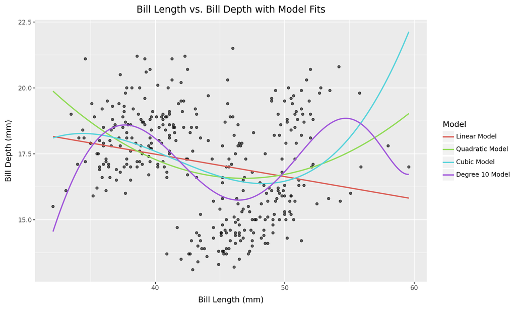

```python
from plotnine import ggplot, aes, geom_point, geom_line, labs, theme
import pandas as pd

# Create a DataFrame for the predicted values
plot_data = pd.DataFrame({
    'bill_length_mm': x_range.flatten(),
    'Linear Model': linear_pred.flatten(),
    'Quadratic Model': quadratic_pred.flatten(),
    'Cubic Model': cubic_pred.flatten(),
    'Degree 10 Model': degree10_pred.flatten()
})

plot = (
    ggplot(data, aes(x='bill_length_mm', y='bill_depth_mm'))
    + geom_point(alpha=0.6)
    + geom_line(plot_data, aes(x='bill_length_mm', y='Linear Model', color="'Linear Model'"), size=1)
    + geom_line(plot_data, aes(x='bill_length_mm', y='Quadratic Model', color="'Quadratic Model'"), size=1)
    + geom_line(plot_data, aes(x='bill_length_mm', y='Cubic Model', color="'Cubic Model'"), size=1)
    + geom_line(plot_data, aes(x='bill_length_mm', y='Degree 10 Model', color="'Degree 10 Model'"), size=1)
    + labs(title='Bill Length vs. Bill Depth with Model Fits',
           x='Bill Length (mm)',
           y='Bill Depth (mm)',
           color='Model')
    + theme(figure_size=(10, 6))
)

plot
```

Are any of the models above underfitting the data? If so, which ones and how can you tell? Are any of thhe models above overfitting the data? If so, which ones and how can you tell? Which of the above models do you think fits the data best and why?

After creating a scatterplot between bill length and depth, it is seemingly uncorrelated, so none of the models seem to fit well. Out of the 4 models the degree 10 model seems to fit the best.